# Atlas Visual Sulawesi

IPM dan Kemiskinan Kabupaten/Kota di Sulawesi Selatan, 2023–2025

Penulis

Tim 3 — Komputasi Statistika Lanjut

Suhartin M (H062261006)

Asyuroh Nurmadanih Tahir (H062261007)

Diterbitkan

10 Oktober 2026

# 1 Ringkasan utama

Atlas ini menyajikan visualisasi Indeks Pembangunan Manusia (IPM) dan kemiskinan kabupaten/kota di Sulawesi Selatan selama 2023–2025. Atlas menggabungkan grafik distribusi dan tren, peta tematik, profil wilayah, serta analisis ketidakpastian dan inferensi visual.

Grafik digunakan untuk merangkum pola yang tampak pada data. Hubungan antara IPM dan kemiskinan yang terlihat dalam grafik tidak dengan sendirinya membuktikan hubungan sebab-akibat.

# 2 Pendahuluan dan makeover grafik

Visualisasi sebelum dan sesudah *makeover* ditampilkan untuk memperlihatkan perubahan dalam keterbacaan, hierarki visual, dan penekanan informasi.

[figure not shown]

Perbandingan grafik sebelum dan sesudah makeover

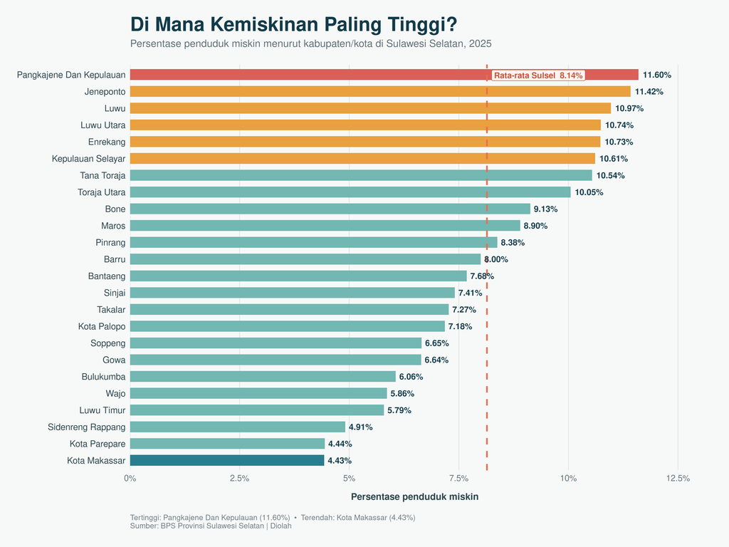

Perbandingan grafik sebelum dan sesudah makeover

# 3 Galeri grafik statistik dan tren indikator

## 3.1 Galeri grafik

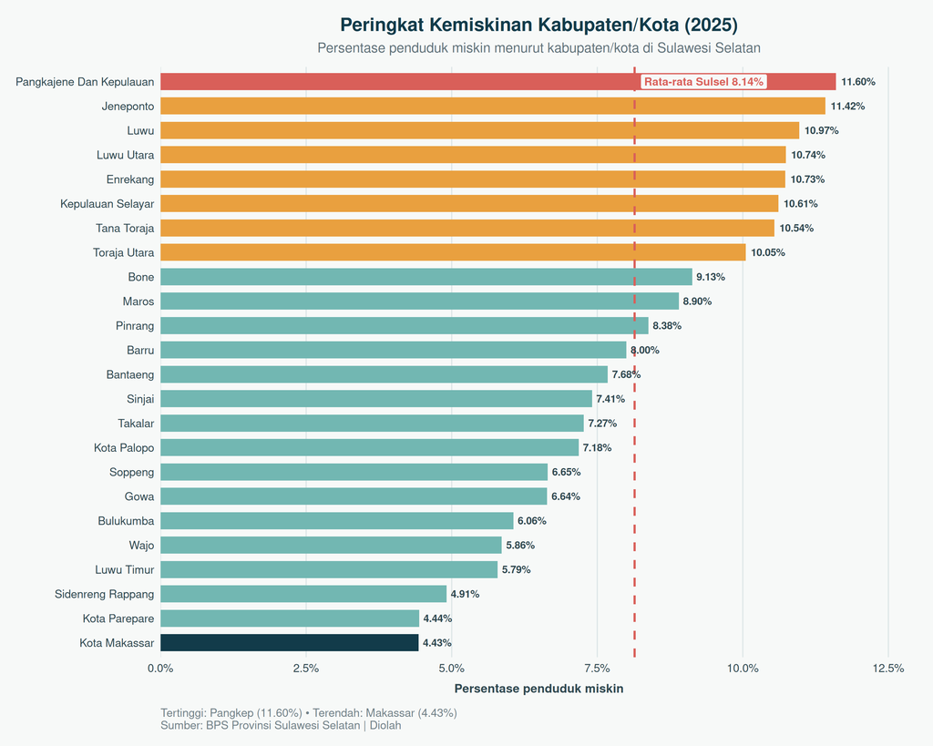

Galeri grafik yang dibuat pada tahap sebelumnya

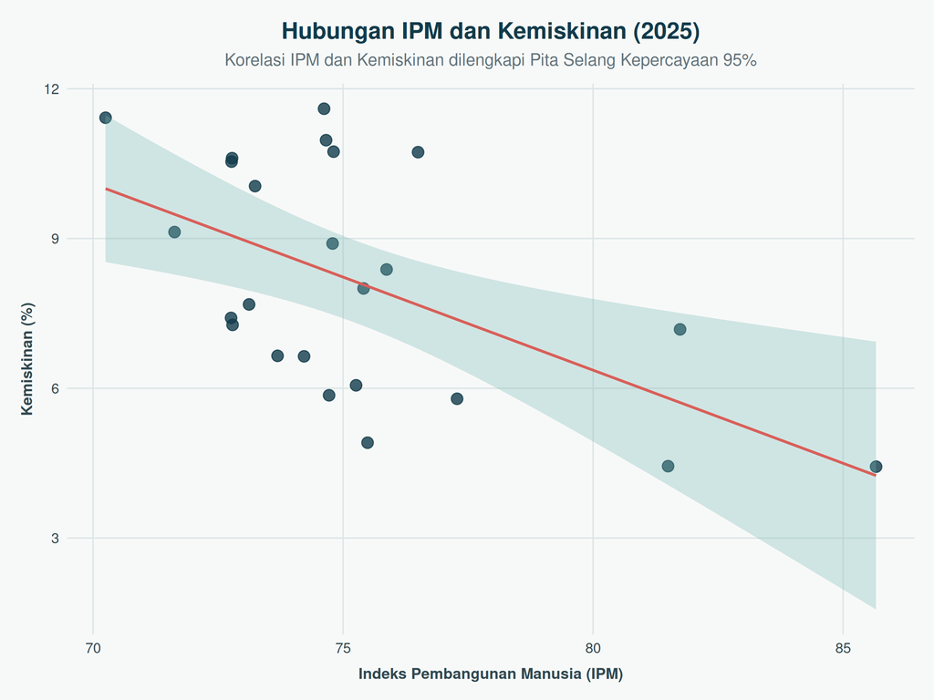

Galeri grafik yang dibuat pada tahap sebelumnya

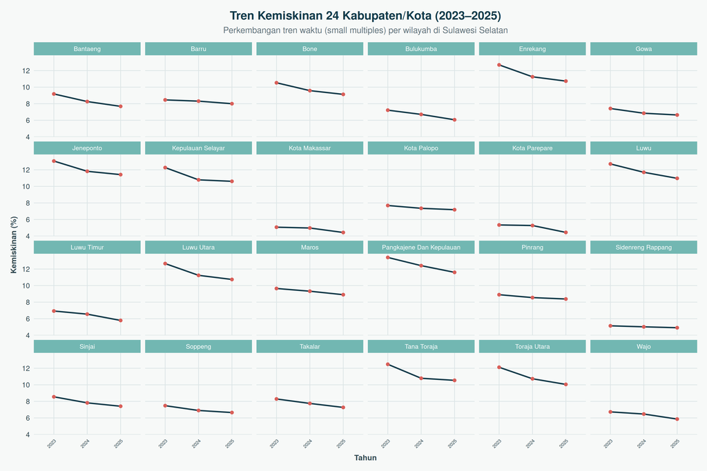

Galeri grafik yang dibuat pada tahap sebelumnya

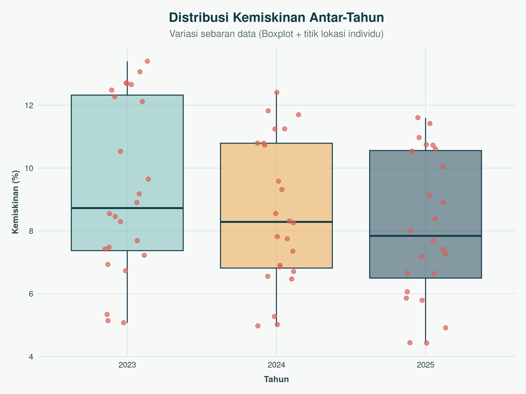

Galeri grafik yang dibuat pada tahap sebelumnya

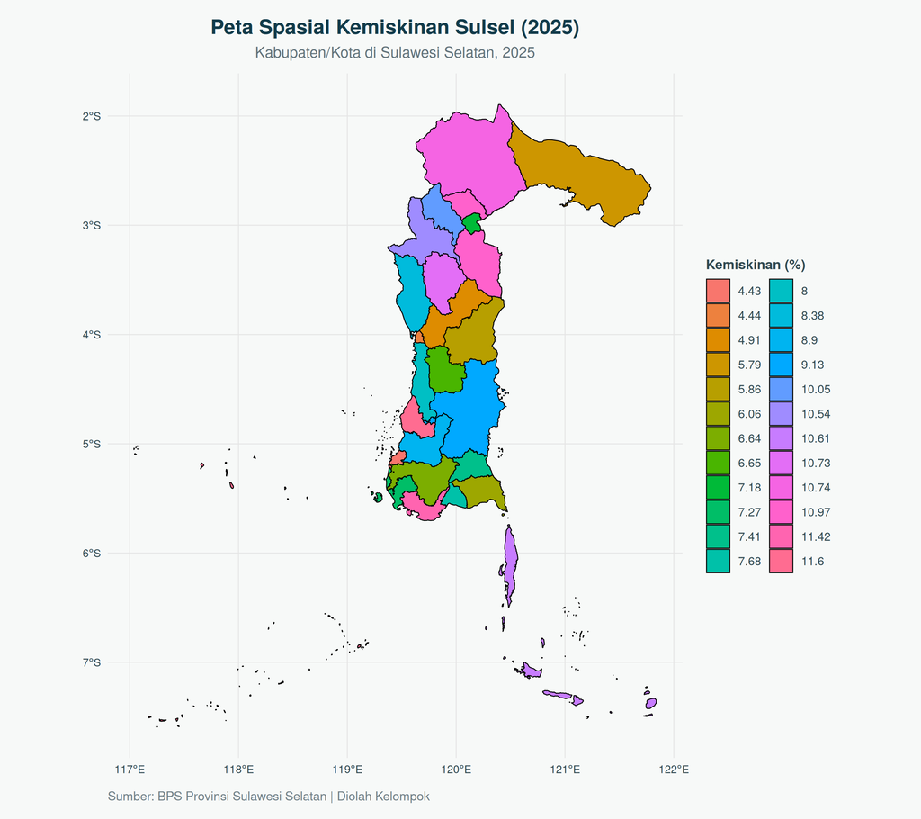

Galeri grafik yang dibuat pada tahap sebelumnya

## 3.2 Distribusi kemiskinan

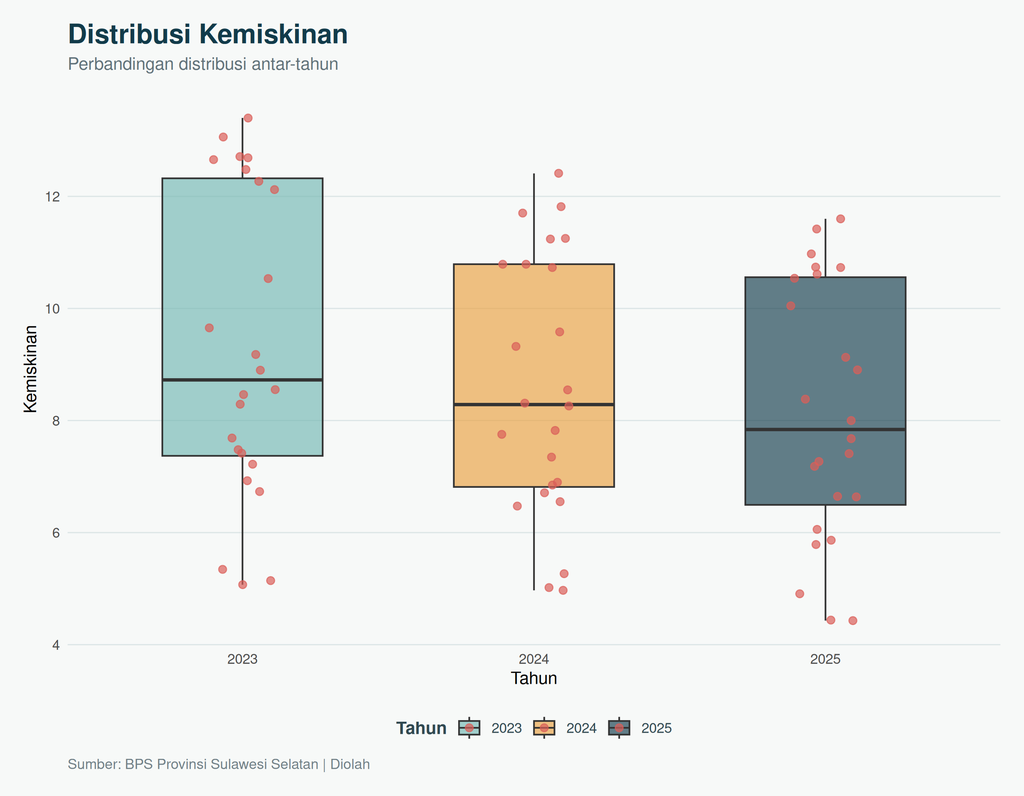

Distribusi kemiskinan kabupaten/kota di Sulawesi Selatan

Grafik distribusi membantu melihat sebaran dan perbedaan tingkat kemiskinan antardaerah. Interpretasi spesifik seperti wilayah dengan nilai tertinggi atau terendah perlu merujuk pada angka dan label yang tercantum di grafik.

## 3.3 Tren kemiskinan

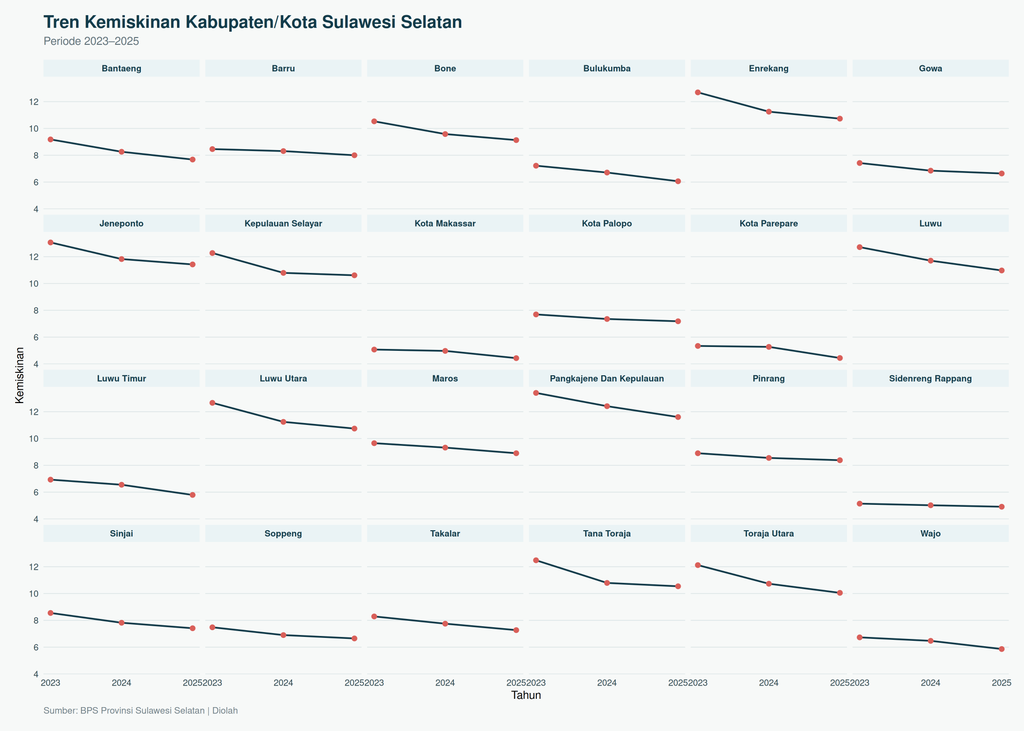

Tren kemiskinan kabupaten/kota Sulawesi Selatan selama periode pengamatan

Grafik tren digunakan untuk membandingkan perubahan indikator kemiskinan sepanjang 2023–2025. Perubahan pada periode pendek ini dideskripsikan sebagai pola dalam data yang diamati, bukan sebagai bukti penyebab perubahan.

## 3.4 Distribusi dan tren IPM

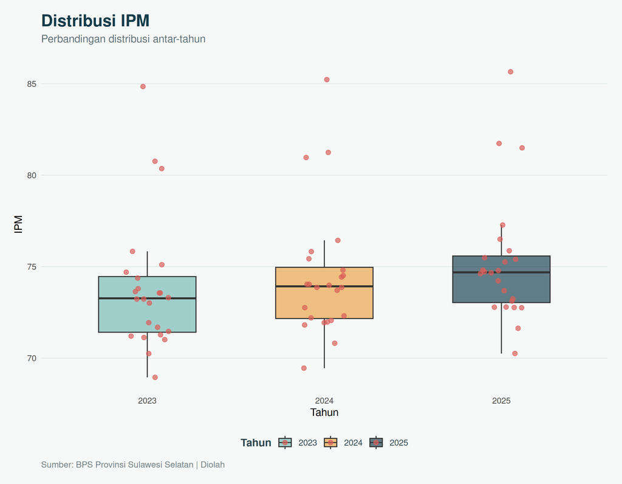

Distribusi IPM kabupaten/kota di Sulawesi Selatan

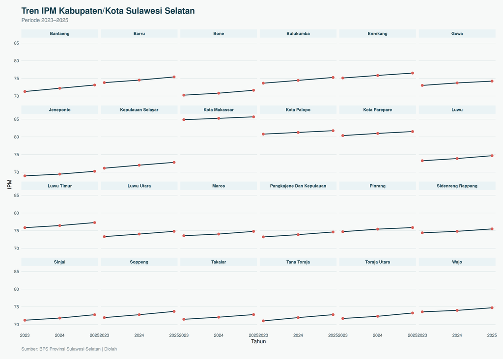

Tren IPM kabupaten/kota Sulawesi Selatan selama periode pengamatan

## 3.5 Komposisi multipanel

[figure not shown]

Komposisi grafik multipanel

# 4 Peta koroplet dan aksesibilitas warna

Peta berikut menunjukkan persebaran kemiskinan tahun 2025. Dua simulasi tambahan digunakan untuk memeriksa keterbedaan warna bagi pembaca dengan kondisi persepsi warna tertentu.

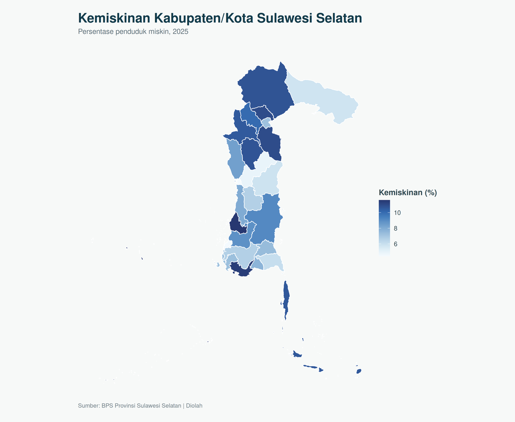

Peta kemiskinan 2025: peta utama, simulasi deuteranopia, dan simulasi protanopia

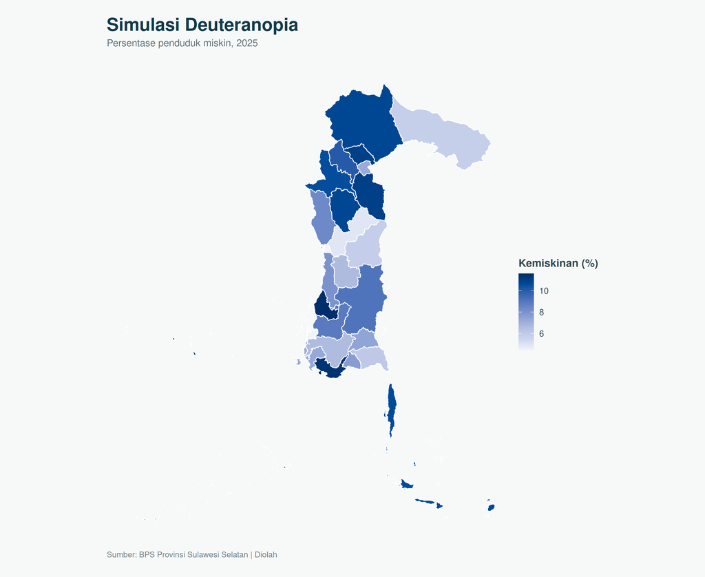

Peta kemiskinan 2025: peta utama, simulasi deuteranopia, dan simulasi protanopia

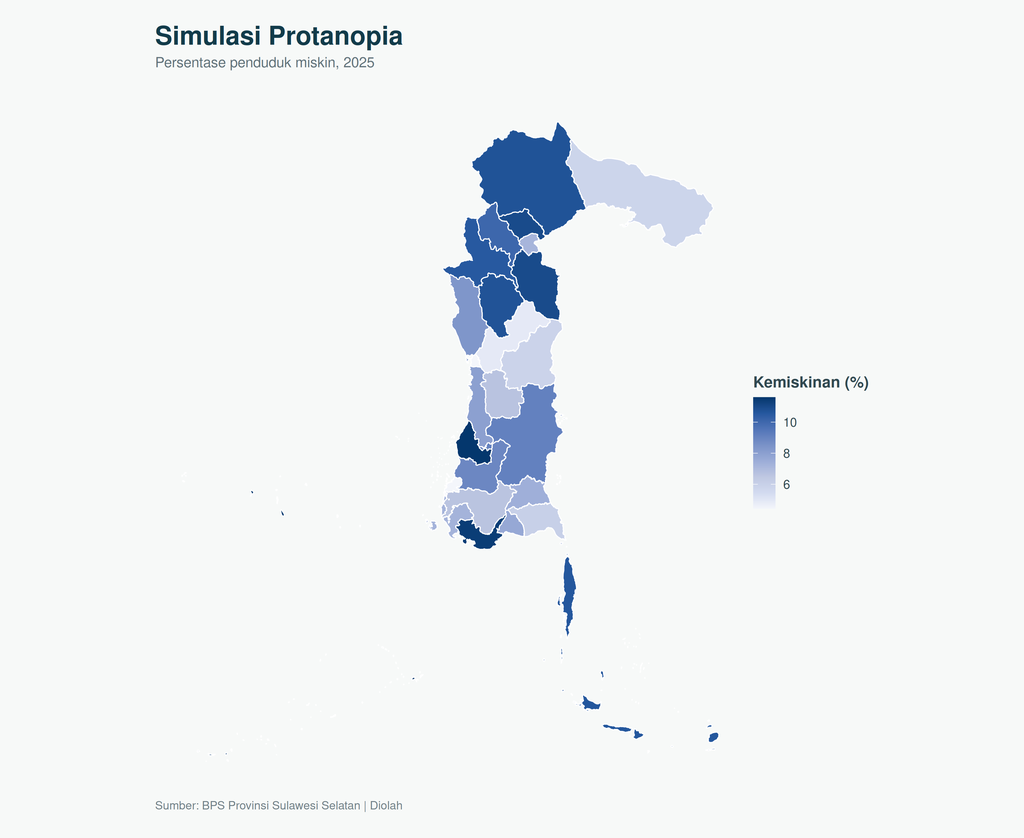

Peta kemiskinan 2025: peta utama, simulasi deuteranopia, dan simulasi protanopia

# 5 Profil 24 kabupaten/kota

Profil wilayah dibuat secara otomatis melalui fungsi grafik yang tersedia dalam skrip R proyek.

### 5.0.1 Bantaeng

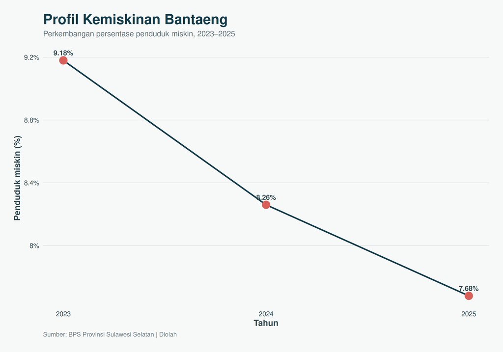

### 5.0.2 Barru

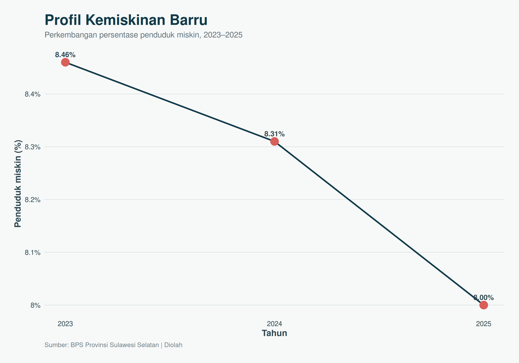

### 5.0.3 Bone

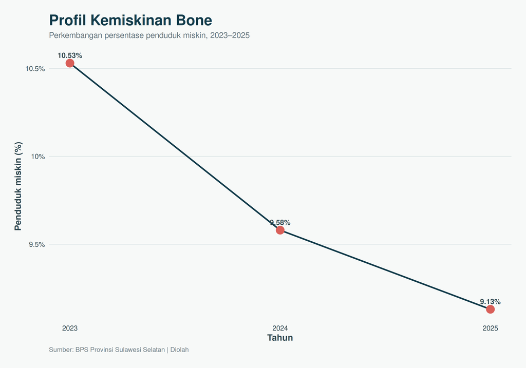

### 5.0.4 Bulukumba

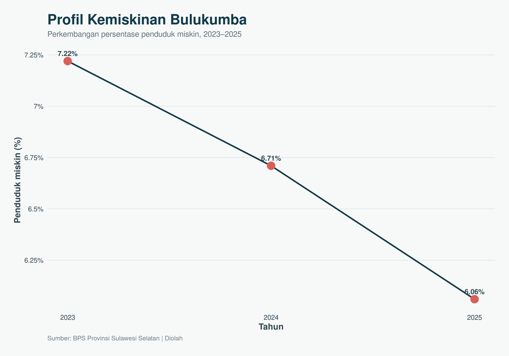

### 5.0.5 Enrekang

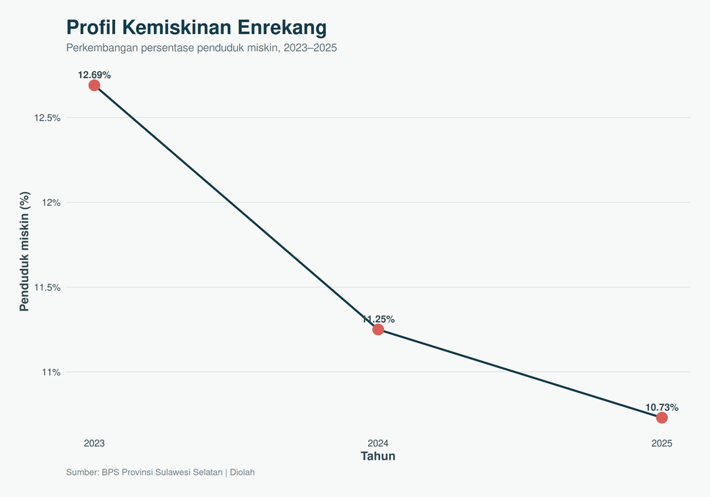

### 5.0.6 Gowa

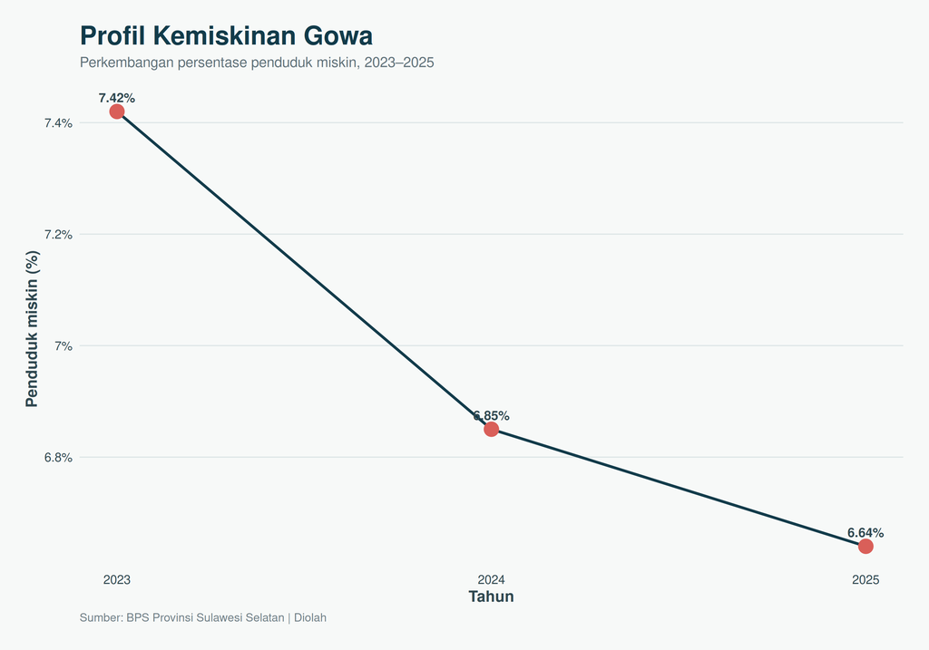

### 5.0.7 Jeneponto

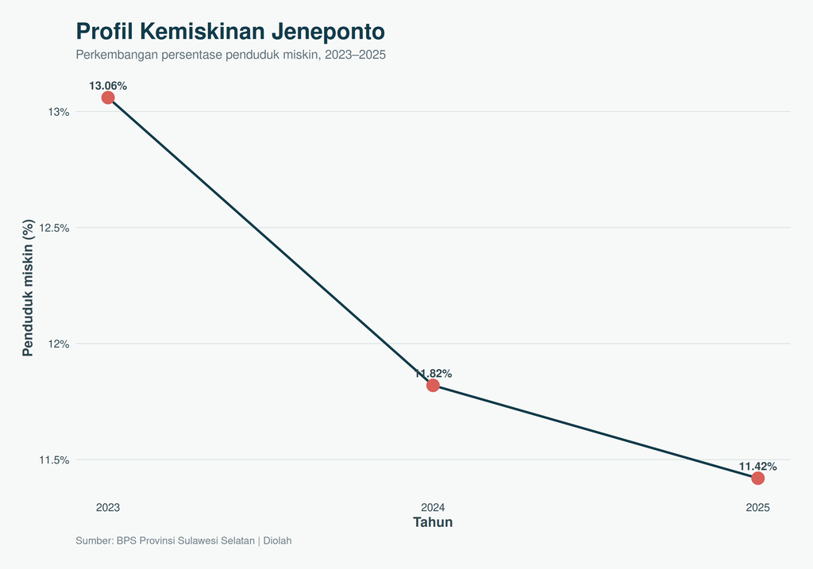

### 5.0.8 Kepulauan Selayar

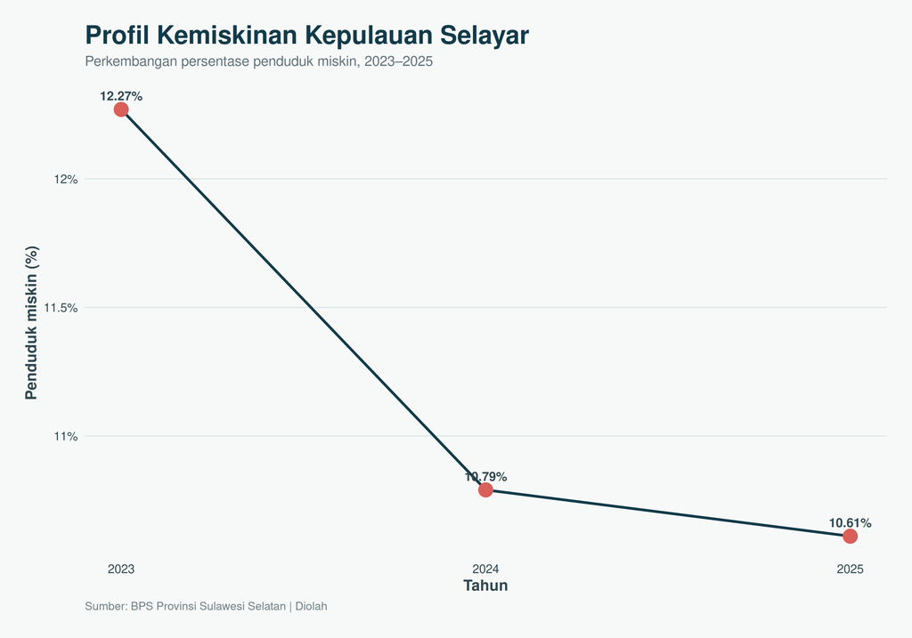

### 5.0.9 Kota Makassar

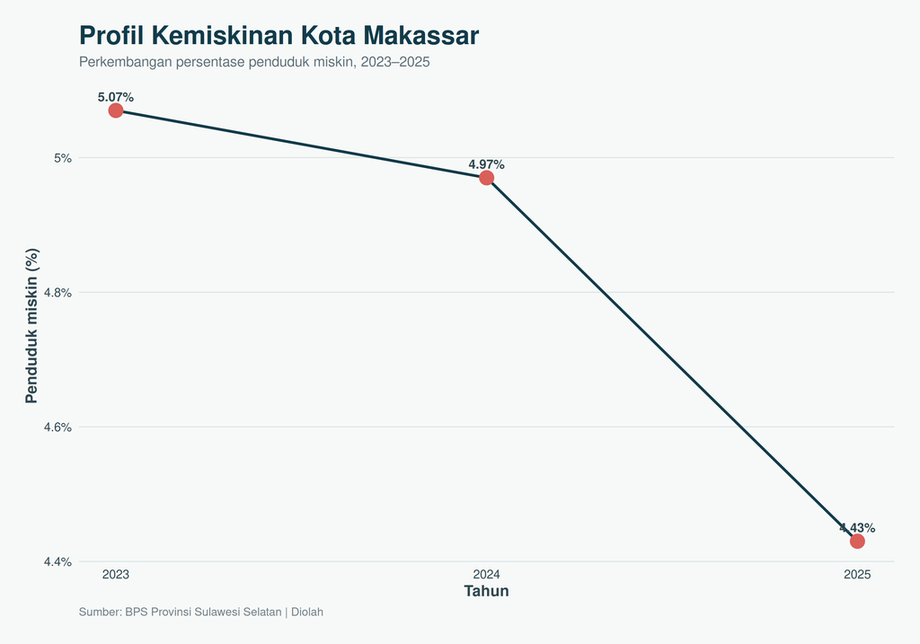

### 5.0.10 Kota Palopo

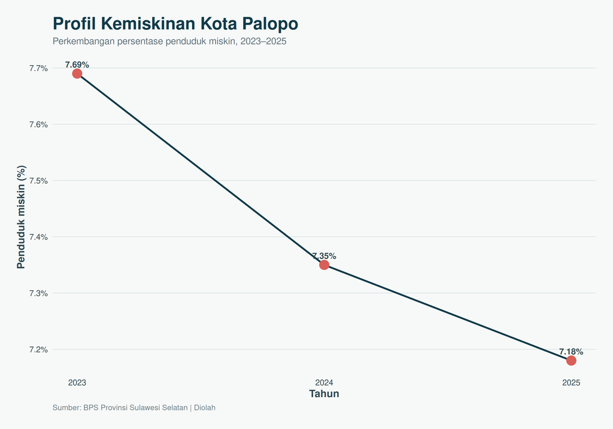

### 5.0.11 Kota Parepare

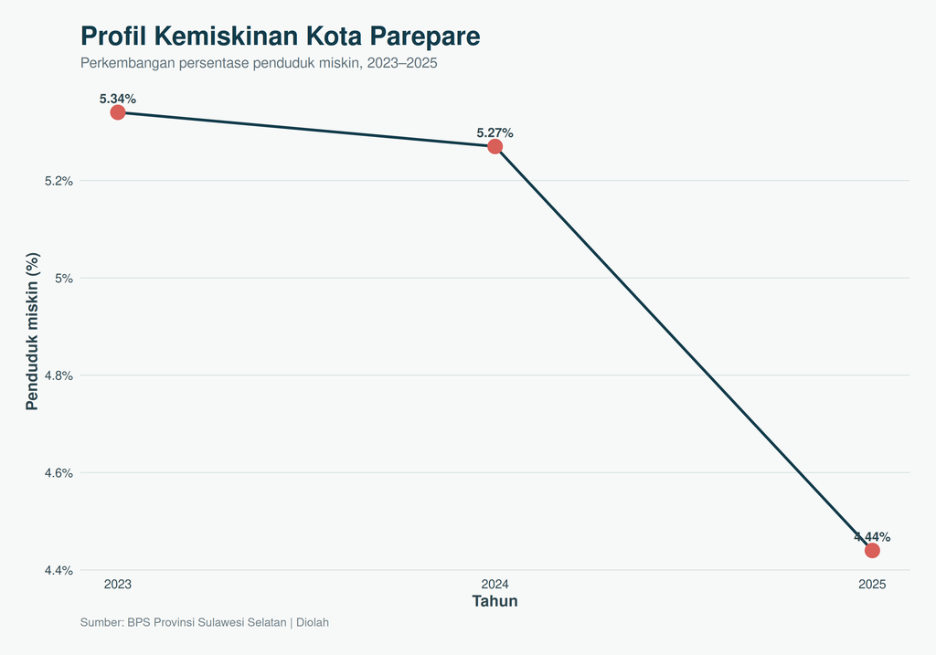

### 5.0.12 Luwu Timur

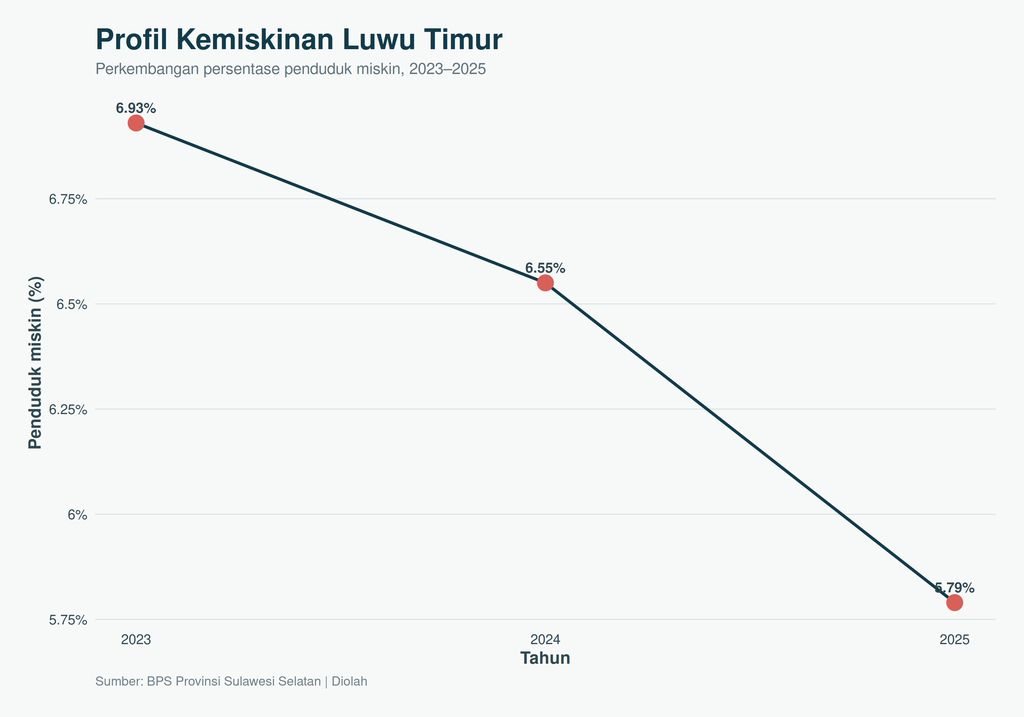

### 5.0.13 Luwu Utara

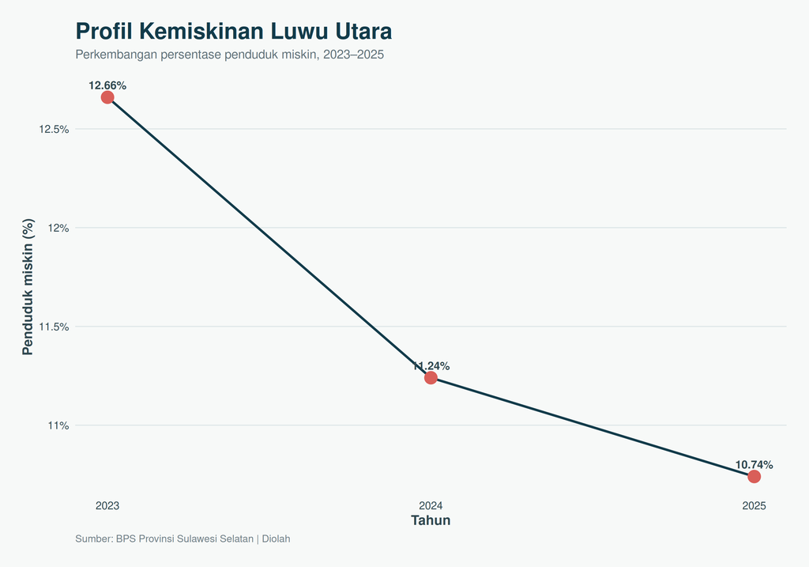

### 5.0.14 Luwu

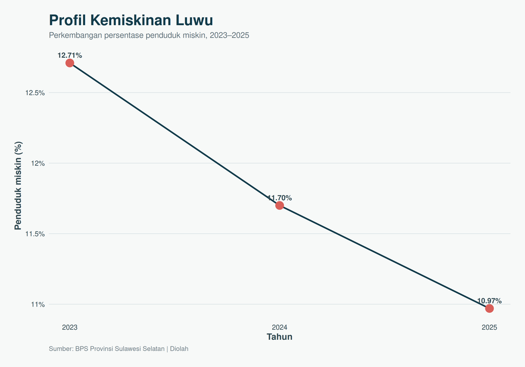

### 5.0.15 Maros

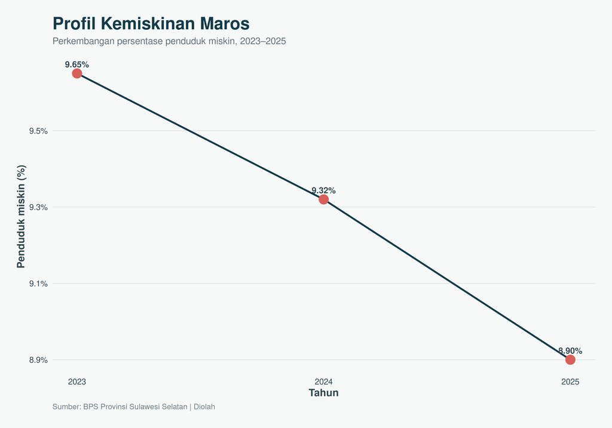

### 5.0.16 Pangkajene Dan Kepulauan

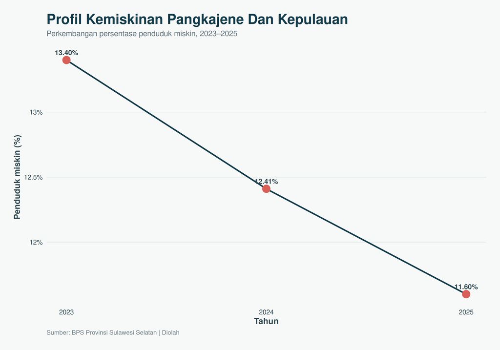

### 5.0.17 Pinrang

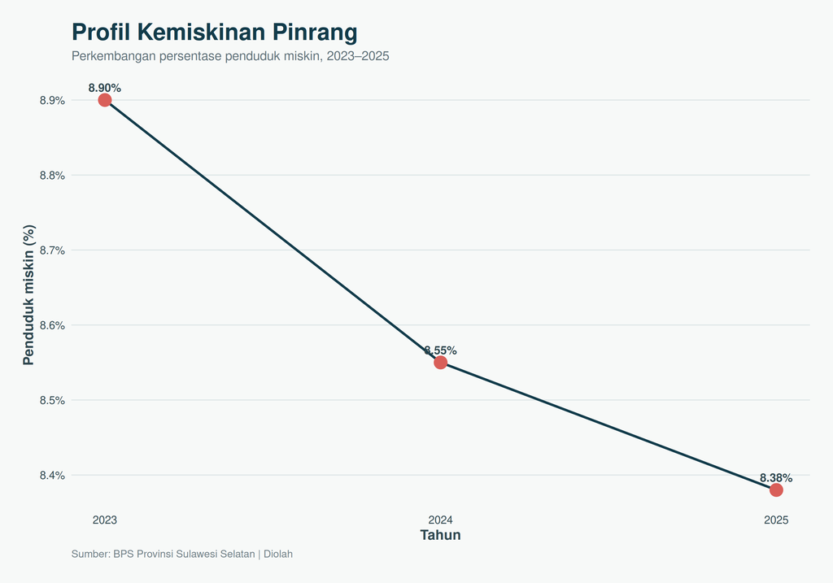

### 5.0.18 Sidenreng Rappang

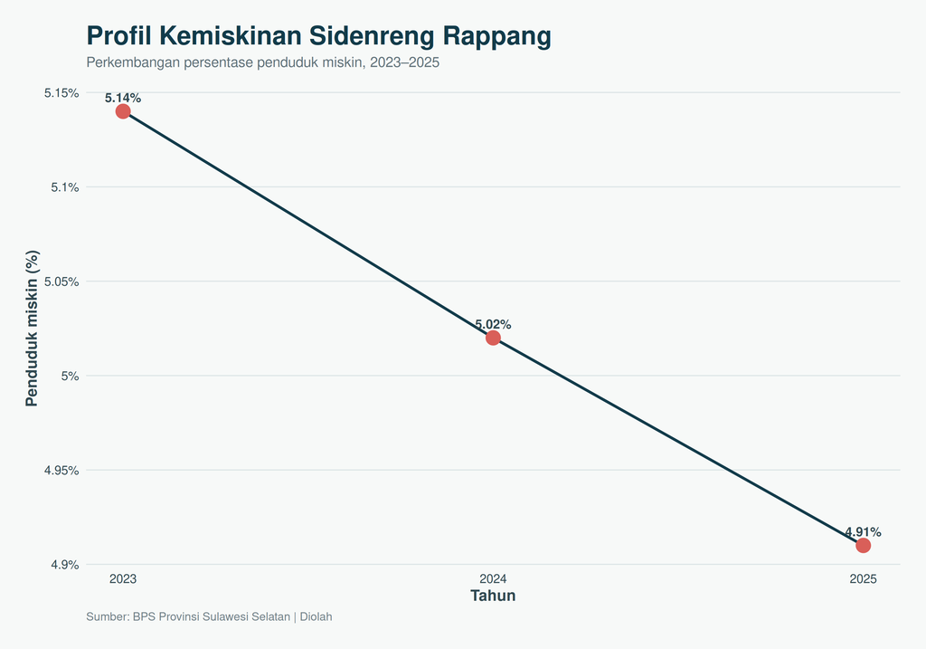